# Predict Bike Sharing Demand with AutoGluon Template

## Make category types for these so models know they are not just numbers

- AutoGluon originally sees these as ints, but in reality they are int representations of a category.
- Setting the dtype to category will classify these as categories in AutoGluon.

```python
train[['season','weather']] = train[['season','weather']].astype('category')
test[['season','weather']] = test[['season','weather']].astype('category')
```

```python
# check the new feature
train.head()
```

[output not shown]

```
array([[<AxesSubplot: title={'center': 'datetime'}>,
        <AxesSubplot: title={'center': 'holiday'}>,
        <AxesSubplot: title={'center': 'workingday'}>,
        <AxesSubplot: title={'center': 'temp'}>],
       [<AxesSubplot: title={'center': 'atemp'}>,
        <AxesSubplot: title={'center': 'humidity'}>,
        <AxesSubplot: title={'center': 'windspeed'}>,
        <AxesSubplot: title={'center': 'casual'}>],
       [<AxesSubplot: title={'center': 'registered'}>,
        <AxesSubplot: title={'center': 'count'}>,
        <AxesSubplot: title={'center': 'month'}>,
        <AxesSubplot: title={'center': 'day'}>],
       [<AxesSubplot: title={'center': 'hour'}>,
        <AxesSubplot: title={'center': 'dayofweek'}>, <AxesSubplot: >,
        <AxesSubplot: >]], dtype=object)
```

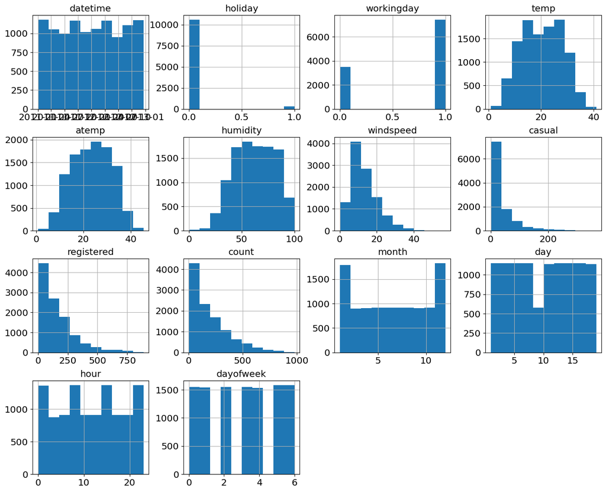

```python
# View histogram of all features again now with the new feature
train.hist()
```

## Rerun the model with the same settings as before, just with more features

```python
predictor_new_features = TabularPredictor(label='count', problem_type='regression', eval_metric='root_mean_squared_error',
learner_kwargs={'ignored_columns': ['casual', 'registered']}).fit(train_data=train, time_limit=600, presets='best_quality')
```

[output not shown]

[output cut: 35 more lines]

```
Fitting model: CatBoost_BAG_L1 ... Training model for up to 245.19s of the 445.17s of remaining time.
	Fitting 8 child models (S1F1 - S1F8) | Fitting with ParallelLocalFoldFittingStrategy
	-33.8296	 = Validation score   (-root_mean_squared_error)
	877.94s	 = Training   runtime
	4.63s	 = Validation runtime
Completed 1/20 k-fold bagging repeats ...
Fitting model: WeightedEnsemble_L2 ... Training model for up to 360.0s of the -464.64s of remaining time.
	-33.1556	 = Validation score   (-root_mean_squared_error)
	1.88s	 = Training   runtime
	0.0s	 = Validation runtime
Fitting 9 L2 models ...
Completed 1/20 k-fold bagging repeats ...
No base models to train on, skipping auxiliary stack level 3...
AutoGluon training complete, total runtime = 1080.08s ... Best model: "WeightedEnsemble_L2"
TabularPredictor saved. To load, use: predictor = TabularPredictor.load("AutogluonModels/ag-20221229_015520/")
```

```python
predictor_new_features.fit_summary()
```

```
*** Summary of fit() ***
Estimated performance of each model:
                    model   score_val  pred_time_val    fit_time  pred_time_val_marginal  fit_time_marginal  stack_level  can_infer  fit_order
0     WeightedEnsemble_L2  -33.155646       5.008877  885.892197                0.001977           1.883696            2       True          7
1         CatBoost_BAG_L1  -33.829628       4.632558  877.937875                4.632558         877.937875            1       True          6
2  RandomForestMSE_BAG_L1  -38.565776       0.330516    6.014804                0.330516           6.014804            1       True          5
3   KNeighborsDist_BAG_L1  -84.125061       0.043826    0.055822                0.043826           0.055822            1       True          2
4   KNeighborsUnif_BAG_L1 -101.546199       0.051330    0.097607                0.051330           0.097607            1       True          1
5         LightGBM_BAG_L1 -173.818077       0.157904   52.388517                0.157904          52.388517            1       True          4
6       LightGBMXT_BAG_L1 -176.199534       0.092516   46.949973                0.092516          46.949973            1       True          3
Number of models trained: 7
Types of models trained:
{'WeightedEnsembleModel', 'StackerEnsembleModel_CatBoost', 'StackerEnsembleModel_KNN', 'StackerEnsembleModel_LGB', 'StackerEnsembleModel_RF'}
Bagging used: True  (with 8 folds)
Multi-layer stack-ensembling used: False
Feature Metadata (Processed):
(raw dtype, special dtypes):
('category', [])             : 2 | ['season', 'weather']
('float', [])                : 3 | ['temp', 'atemp', 'windspeed']
('int', [])                  : 5 | ['humidity', 'month', 'day', 'hour', 'dayofweek']
('int', ['bool'])            : 2 | ['holiday', 'workingday']
('int', ['datetime_as_int']) : 5 | ['datetime', 'datetime.year', 'datetime.month', 'datetime.day', 'datetime.dayofweek']
*** End of fit() summary ***
```

[output not shown]

[output cut: 40 more lines]

```
 1                4.632558         877.937875            1       True
 2                0.330516           6.014804            1       True
 3                0.043826           0.055822            1       True
 4                0.051330           0.097607            1       True
 5                0.157904          52.388517            1       True
 6                0.092516          46.949973            1       True

    fit_order
 0          7
 1          6
 2          5
 3          2
 4          1
 5          4
 6          3  }
```

```python
# Remember to set all negative values to zero
predictions_new_features = predictor_new_features.predict(test)
predictions_new_features = predictions_new_features.map(lambda x: max(0, x))
```

```python
# Same submitting predictions
submission_new_features = submission.copy()
submission_new_features["count"] = predictions_new_features.values
submission_new_features.to_csv("submission_new_features.csv", index=False)
```

```python
!kaggle competitions submit -c bike-sharing-demand -f submission_new_features.csv -m "new features"
```

```python
!kaggle competitions submissions -c bike-sharing-demand | tail -n +1 | head -n 6
```

#### New Score of `0.56122`

## Hyperparameter Optimization

- **Variety of Options:** Hyperparameter optimization offers numerous strategies.
- **Options to Explore:** These include adjusting higher-level parameters of AutoGluon or tuning individual model hyperparameters.
- **Model Hyperparameters:** For the models within AutoGluon, specifying hyperparameters requires utilizing the `hyperparameter` and `hyperparameter_tune_kwargs` arguments.

```python
from autogluon.core.space import Categorical, Int, Real
from autogluon.tabular import TabularPredictor

# Define custom hyperparameters for Random Forest model
custom_hyperparameters_hpo = {
    "RF": {
        'max_depth': Int(lower=3, upper=30),
        'max_features': Real(lower=0.1, upper=1.0),
        'max_samples': Real(lower=0.1, upper=1.0)
    }
}

# Create a TabularPredictor with specified settings
predictor_new_hpo = TabularPredictor(label='count',
                                      problem_type='regression',
                                      eval_metric='root_mean_squared_error',
                                      learner_kwargs={'ignored_columns': ['casual', 'registered']}
                                      ).fit(train_data=train,
                                             hyperparameters=custom_hyperparameters_hpo,
                                             hyperparameter_tune_kwargs={'auto': True},
                                             time_limit=600,
                                             presets='best_quality')
```

[output not shown]

[output cut: 629 more lines]

```
Fitted model: RandomForest_BAG_L2/T4 ...
	-35.9102	 = Validation score   (-root_mean_squared_error)
	27.3s	 = Training   runtime
	0.0s	 = Validation runtime
Fitted model: RandomForest_BAG_L2/T5 ...
	-36.0503	 = Validation score   (-root_mean_squared_error)
	52.97s	 = Training   runtime
	0.0s	 = Validation runtime
Completed 1/20 k-fold bagging repeats ...
Fitting model: WeightedEnsemble_L3 ... Training model for up to 360.0s of the 24.52s of remaining time.
	-35.8738	 = Validation score   (-root_mean_squared_error)
	0.36s	 = Training   runtime
	0.0s	 = Validation runtime
AutoGluon training complete, total runtime = 576.1s ... Best model: "WeightedEnsemble_L3"
TabularPredictor saved. To load, use: predictor = TabularPredictor.load("AutogluonModels/ag-20221229_030258/")
```

```python
predictor_new_hpo.fit_summary()
```

```
*** Summary of fit() ***
Estimated performance of each model:
                        model   score_val  pred_time_val    fit_time  pred_time_val_marginal  fit_time_marginal  stack_level  can_infer  fit_order
0         WeightedEnsemble_L3  -35.873764       0.038174  465.723674                0.000865           0.364259            3       True        136
1      RandomForest_BAG_L2/T4  -35.910193       0.036833  379.157550                0.000261          27.295662            2       True        134
2      RandomForest_BAG_L2/T3  -36.041327       0.036738  385.096692                0.000167          33.234803            2       True        133
3      RandomForest_BAG_L2/T5  -36.050258       0.036881  404.828950                0.000310          52.967062            2       True        135
4      RandomForest_BAG_L2/T2  -36.185347       0.036870  424.873649                0.000298          73.011760            2       True        132
5         WeightedEnsemble_L2  -37.016080       0.003412   16.164522                0.002024           0.515656            2       True        130
6    RandomForest_BAG_L1/T101  -37.585391       0.000336    3.443419                0.000336           3.443419            1       True        101
7    RandomForest_BAG_L1/T114  -37.650166       0.000323    3.126389                0.000323           3.126389            1       True        114
8     RandomForest_BAG_L1/T66  -37.658222       0.000279    3.530771                0.000279           3.530771            1       True         66
9    RandomForest_BAG_L1/T102  -37.744479       0.000252    2.599476                0.000252           2.599476            1       True        102
10    RandomForest_BAG_L1/T49  -37.751535       0.000197    2.948811                0.000197           2.948811            1       True         49
11    RandomForest_BAG_L1/T63  -37.786047       0.000286    2.792439                0.000286           2.792439            1       True         63
```

[output cut: 137 more lines]

[output not shown]

[output cut: 1346 more lines]

```

      fit_order
 0          136
 1          134
 2          133
 3          135
 4          132
 ..         ...
 131        116
 132         28
 133         12
 134          1
 135         15

 [136 rows x 9 columns]}
```

```python
# Remember to set all negative values to zero
predictions_new_hpo = predictor_new_hpo.predict(test)
predictions_new_hpo = predictions_new_hpo.map(lambda x: max(0, x))
```

```python
# Same submitting predictions

submission_new_hpo = submission.copy()
submission_new_hpo["count"] = predictions_new_hpo.values
submission_new_hpo.to_csv("submission_new_hpo.csv", index=False)
```

```python
!kaggle competitions submit -c bike-sharing-demand -f submission_new_hpo.csv -m "new features with hyperparameters"
```

```python
!kaggle competitions submissions -c bike-sharing-demand | tail -n +1 | head -n 6
```

#### New Score of `0.49164`

## Write a Report

### Refer to the markdown file for the full report

### Creating plots and table for report

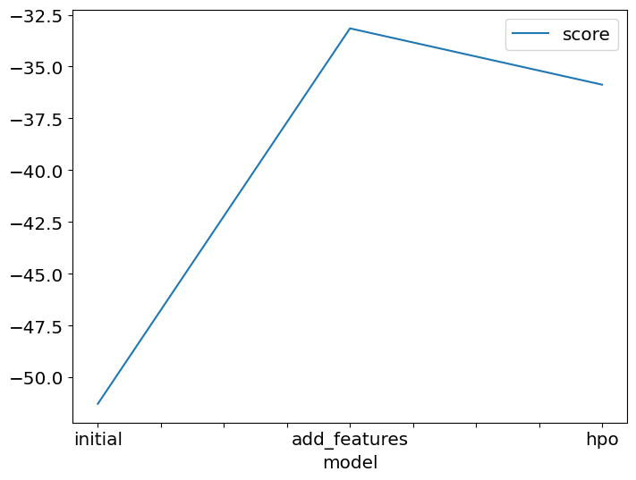

```python
# Taking the top model score from each training run and creating a line plot to show improvement
# You can create these in the notebook and save them to PNG or use some other tool (e.g. google sheets, excel)
fig = pd.DataFrame(
    {
        "model": ["initial", "add_features", "hpo"],
        "score": [predictor.leaderboard(silent=True)['score_val'][0],
          predictor_new_features.leaderboard(silent=True)['score_val'][0],
          predictor_new_hpo.leaderboard(silent=True)['score_val'][0]]
    }
).plot(x="model", y="score", figsize=(8, 6)).get_figure()
fig.savefig('img/model_train_score.png')
```

[figure not shown]

```python
# Create DataFrame for the Kaggle scores
scores_df = pd.DataFrame({
    "test_eval": ["initial", "add_features", "hpo"],
    "score": [1.82358, 0.56122, 0.49164]
})

# Create a line plot to visualize the improvement
fig, ax = plt.subplots(figsize=(8, 6))
scores_df.plot(x="test_eval", y="score", ax=ax)
ax.set_xlabel("Test Evaluation")
ax.set_ylabel("Score")
ax.set_title("Model Test Scores")
plt.tight_layout()

# Save the plot as an image
plt.savefig('img/model_test_score.png')
```

### Hyperparameter table

```python
# Obtain the leaderboard and select the best model
leaderboard_hpo = predictor_new_hpo.leaderboard(silent=True)
best_model_name = leaderboard_hpo[leaderboard_hpo['stack_level'] == 1]['model'].iloc[0]

# Retrieve information about the best model
predictor_info = predictor_new_hpo.info()
best_model_info = predictor_info['model_info'][best_model_name]
```

```python
print(best_model_info)
```

[output not shown]

```python
# Create a DataFrame to summarize the tuned hyperparameters and corresponding Kaggle scores
hyperparameter_summary = pd.DataFrame({
    "model": ['initial', 'add_features', 'hpo'],
    "hpo1": ['default', 'default', 'max_depth: 16'],
    "hpo2": ['default', 'default', 'max_features: 0.77379'],
    "hpo3": ['default', 'default', 'max_samples: 0.91334'],
    "score": [1.82358, 0.56122, 0.49164]
})
```

|  | model | hpo1 | hpo2 | hpo3 | score |
| --- | --- | --- | --- | --- | --- |
| 0 | initial | default | default | default | 1.82358 |
| 1 | add_features | default | default | default | 0.56122 |
| 2 | hpo | max_depth: 16 | max_features: 0.77379 | max_samples: 0.91334 | 0.49164 |